# Frontloading Analysis after glmmSeq, Slope as Base Level

Zoe Dellaert

4/24/2023

This is a Rmd file analyzing our predicted gene expression data which was analyzed with the glmmSeq package as described in the [vignette](https://cran.r-project.org/web/packages/glmmSeq/vignettes/glmmSeq.html) and [manual](https://cran.r-project.org/web/packages/glmmSeq/glmmSeq.pdf).

```r
library(dplyr)
library(reshape2)
```

From glmmSeq, I saved the following output:

- “signif_genes_rawcts.csv” #save this as csv for downstream analysis
- “signif_genes_cts.csv” #save this as csv for downstream analysis
- “signif_genes_normcts.csv” #save this as csv for downstream analysis

I am going to start by using the normalized counts data frame, we can change this if needed. Most of the analysis uses the first 29 columns, which is the same for all 3 csvs.

```r
DEGs <- read.csv(file="../../../output/glmmseq/signif_genes_normcts.csv", sep=',', header=TRUE)  %>% dplyr::select(!c('X'))

rownames(DEGs) <- DEGs$Gene
```

Lets also pull in our metadata

```r
coldata <- read.csv("../../../../TagSeq_Submission/RNA Submission Sample List metadata.csv") #read in metadata file
coldata <- plyr::rename(coldata, c("Sample.Name"="Coral_ID")) #Make a column that represents the colonies
coldata$Colony <- gsub("A", "", coldata$Coral_ID) #ID which sample is from which colony by remobing letters after colony name
coldata$Colony <- gsub("B", "", coldata$Colony) #ID which sample is from which colony by remobing letters after colony name
coldata$Colony <- gsub("C", "", coldata$Colony) #ID which sample is from which colony by remobing letters after colony name
coldata$Colony <- gsub("D", "", coldata$Colony) #ID which sample is from which colony by remobing letters after colony name

coldata$Origin <- factor(coldata$Origin) #set variables to factors
coldata$Colony <- factor(coldata$Colony) #set variables to factors
coldata$Treatment <- factor(coldata$Treatment) #set variables to factors

coldata <- coldata %>% filter(Coral_ID != c("RF16A","RF16C")) #removed outlier rows from metadata
head(coldata)
```

```
##   Coral_ID Origin Treatment Colony
## 1    RF13B   Flat  Variable   RF13
## 2    RF13D   Flat    Stable   RF13
## 3    RF14B   Flat  Variable   RF14
## 4    RF14C   Flat    Stable   RF14
## 5    RF15B   Flat  Variable   RF15
## 6    RF15D   Flat    Stable   RF15
```

## Frontloading analysis, based on Sam Gurr’s Script: https://github.com/SamGurr/Pgenerosa_OA_TagSeq/blob/e3f27237009d0316533d1548134a1b88a7b86d89/TagSeq/Analysis/Scripts/DE_frontloading.R from *Gurr, S. J., Trigg, S. A., Vadopalas, B., Roberts, S. B., & Putnam, H. M. (2022). Acclimatory gene expression of primed clams enhances robustness to elevated pCO2. Molecular Ecology, 31(19), 5005–5023. https://doi.org/10.1111/mec.16644*

```r
melted <- DEGs %>% dplyr::select(c('Gene',coldata$Coral_ID)) %>%  #keep only the columns with the gene name and normalized count per sample
            reshape2::melt(id.var = 'Gene') %>% #melt by Gene so it is in long form with one observation of a gene-sample pair and its normalized count per row, 414506 rows for 9011 genes * 46 samples
            dplyr::rename(Coral_ID = variable) %>% dplyr::rename(norm_count = value)

melted_merge <- merge(melted, coldata, by = 'Coral_ID') %>%
                        dplyr::group_by(Gene, Origin, Treatment) %>%  #should  I only group by origin here or by treatment and origin?
                        dplyr::select(!'Coral_ID') %>%
                        dplyr::summarise(meanExp = mean(norm_count))
#this gives us a mean expression value per condition, which we already had through glmmSeq  (predData)

melted_merge_READY <- dcast(melted_merge, Gene ~ Origin + Treatment)
```

Let’s see if the means calculated here match with what glmmSeq predicted

```r
glmmSeq_predict <- read.csv(file="../../../output/glmmseq/model_expression_prediction_allgenes.csv", sep=',', header=TRUE) %>% dplyr::rename("Gene" = 'X')

READY <- glmmSeq_predict %>%
    dplyr::select(!contains("LCI_")) %>% #drop the confidence interval columns for now
    dplyr::select(!contains("UCI_")) %>% #drop the confidence interval columns for now
    dplyr::arrange(Gene) # sort by gene name
```

```r
#for our purposes, conditioned = Flat and naive = Slope, Ambient = Stable, and Moderate = Variable

# X axis - this is the relative fold ratio of the conditioned-control to the naive-control as the following:
# [ (Variable_Flat/Stable_Flat) / (Variable_Slope/Stable_Slope) ]
# like a ratio of a ratio.. the values <1 will indicate genes that are lower response to stress than the naive animals (opposite for values >1)

# lets calculate it

colnames(READY)
```

```
## [1] "Gene"             "y_Stable_Slope"   "y_Variable_Slope" "y_Stable_Flat"
## [5] "y_Variable_Flat"
```

```r
xall_1 <- ( (READY$y_Variable_Flat / READY$y_Stable_Flat) / (READY$y_Variable_Slope / READY$y_Stable_Slope) ) # call y_Stable_Flat as the control for the y_Variable_Flat ratio

xall_2 <- ( (READY$y_Variable_Flat / READY$y_Stable_Slope) / (READY$y_Variable_Slope / READY$y_Stable_Slope) ) # call y_Stable_Slope as the control for the y_Variable_Flat ratio

xall_3 <- (READY$y_Variable_Flat / READY$y_Variable_Slope)  # call y_Stable_Slope as the control for the y_Variable_Flat ratio

# Xall 2 and Xall3 are the exact same ratios.

READY$xall_1 <- xall_1
READY$xall_2 <- xall_2
READY$xall_3 <- xall_3

# Y Axis - this is simply the conditioned control over the naive control

# lets calculate it
yall <- (READY$y_Variable_Flat / READY$y_Stable_Slope)

READY$yall <- yall
```

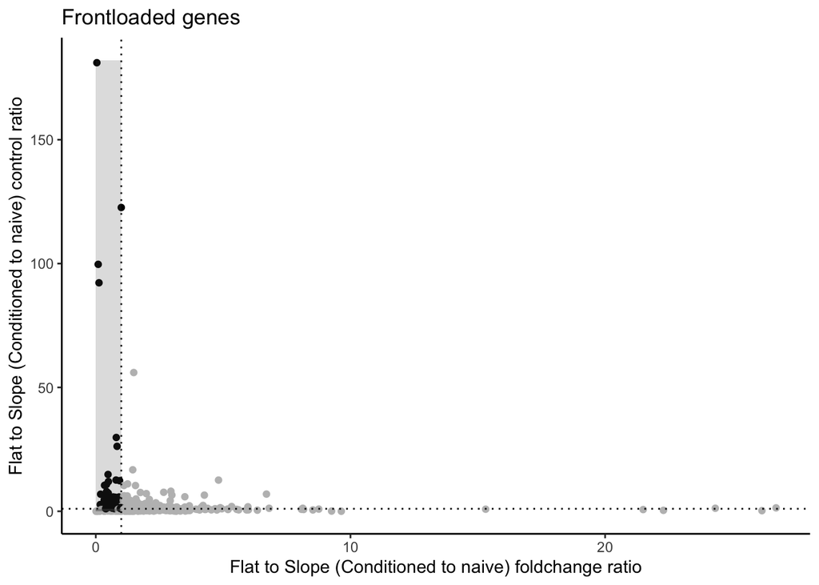

```r
# lets plot it!
library(ggplot2)


READY$color <- rep('gray', nrow(READY))
#These are "frontloaded, need a different color:
READY$color[READY$yall > 1 & READY$xall_1 < 1] <- 'black'

write.csv(READY, "../../../output/glmmseq/frontloaded_genes_plotting.csv")

P_allgenes <- READY %>% #dplyr::filter(yall < 6) %>%
        ggplot(aes(x=xall_1, y=yall)) +
        geom_point(colour = READY$color) +
        theme_classic() +
        geom_vline(xintercept=1, linetype="dotted") +
        geom_hline(yintercept=1, linetype="dotted") +
        labs(y= "Flat to Slope (Conditioned to naive) control ratio",
             x = "Flat to Slope (Conditioned to naive) foldchange ratio",
             title = "Frontloaded genes") +
        annotate("rect", xmin = 0, xmax = 1, ymin = 1, ymax = max(yall) + 1, alpha = .2) +
        annotate("rect", xmin = 0, xmax = 1, ymin = 0, ymax = 1,alpha = .5)

P_allgenes
```

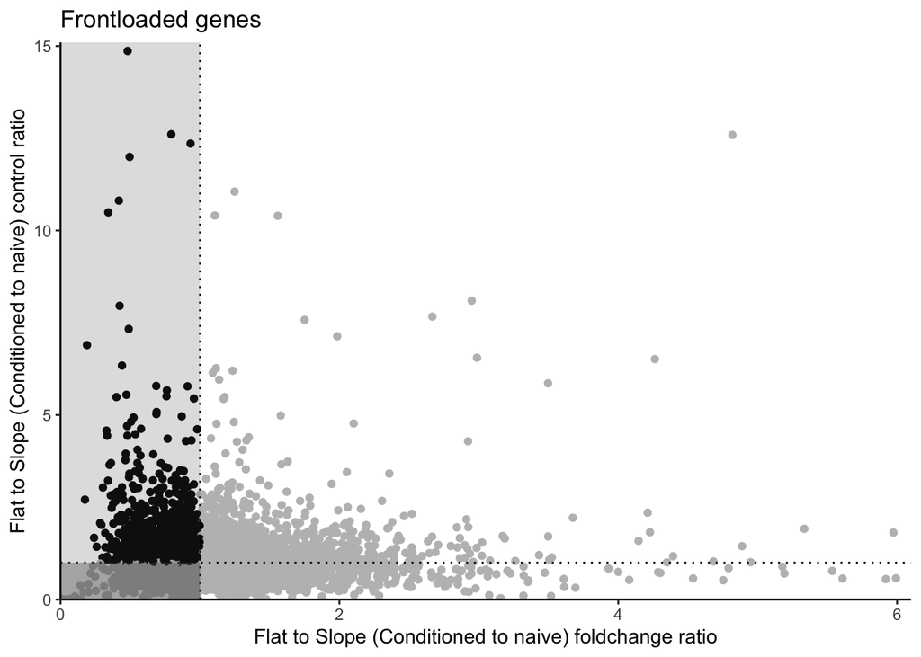

```r
READY_cutoff <- READY %>% dplyr::filter(yall < 20) %>% dplyr::filter(xall_1 < 6)

P <- READY_cutoff %>%
        ggplot(aes(x=xall_1, y=yall)) +
        geom_point(colour = READY_cutoff$color) +
        theme_classic() +
        geom_vline(xintercept=1, linetype="dotted") +
        geom_hline(yintercept=1, linetype="dotted") +
        labs(y= "Flat to Slope (Conditioned to naive) control ratio",
             x = "Flat to Slope (Conditioned to naive) foldchange ratio",
             title = "Frontloaded genes") +
        scale_x_continuous(limits = c(0,6.1),expand = c(0, 0)) + scale_y_continuous(limits = c(0,15.1), expand = c(0, 0)) +
        annotate("rect", xmin = 0, xmax = 1, ymin = 1, ymax = 15.1, alpha = .2) +
        annotate("rect", xmin = 0, xmax = 1, ymin = 0, ymax = 1,alpha = .5)

P
```

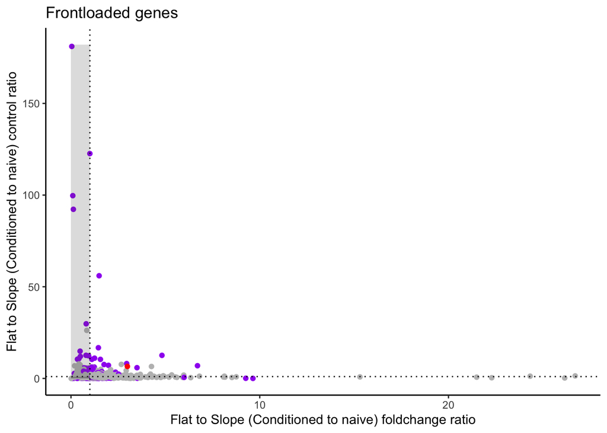

```r
#color DE genes by origin

DEGs_Origin <- DEGs %>%
  filter(Origin < 0.05) %>%
  pull(Gene)

DEGs_Treatment <- DEGs %>%
  filter(Treatment < 0.05) %>%
  pull(Gene)

READY$color <- rep('gray', nrow(READY))
#These are "frontloaded, need a different color:
#READY$color[READY$yall > 1 & READY$xall_1 < 1] <- 'black'
READY$color[READY$Gene %in% DEGs_Origin] <- 'purple'
READY$color[READY$Gene %in% DEGs_Treatment] <- 'red'

P_allgenes <- READY %>% #dplyr::filter(yall < 6) %>%
        ggplot(aes(x=xall_1, y=yall)) +
        geom_point(colour = READY$color) +
        theme_classic() +
        geom_vline(xintercept=1, linetype="dotted") +
        geom_hline(yintercept=1, linetype="dotted") +
        labs(y= "Flat to Slope (Conditioned to naive) control ratio",
             x = "Flat to Slope (Conditioned to naive) foldchange ratio",
             title = "Frontloaded genes") +
        annotate("rect", xmin = 0, xmax = 1, ymin = 1, ymax = max(yall) + 1, alpha = .2) +
        annotate("rect", xmin = 0, xmax = 1, ymin = 0, ymax = 1,alpha = .5)

P_allgenes
```

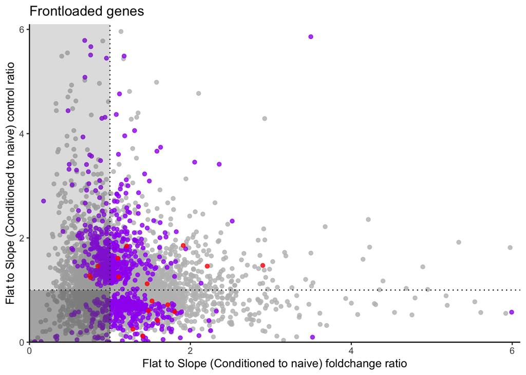

```r
READY_cutoff <- READY %>% dplyr::filter(yall < 6) %>% dplyr::filter(xall_1 < 6)

P <- READY_cutoff %>%
        ggplot(aes(x=xall_1, y=yall)) +
        #geom_point(colour = READY_cutoff$color, alpha=0.8) +
        geom_point(data = subset(READY_cutoff, READY_cutoff$color == "gray"), colour = subset(READY_cutoff$color, READY_cutoff$color == "gray"), alpha = 0.8) +
        geom_point(data = subset(READY_cutoff, READY_cutoff$color == "purple"), colour = subset(READY_cutoff$color, READY_cutoff$color == "purple"), alpha = 0.8) +
        geom_point(data = subset(READY_cutoff, READY_cutoff$color == "red"), colour = subset(READY_cutoff$color, READY_cutoff$color == "red"), alpha = 0.8) +
        theme_classic() +
        geom_vline(xintercept=1, linetype="dotted") +
        geom_hline(yintercept=1, linetype="dotted") +
        labs(y= "Flat to Slope (Conditioned to naive) control ratio",
             x = "Flat to Slope (Conditioned to naive) foldchange ratio",
             title = "Frontloaded genes") +
        scale_x_continuous(limits = c(0,6.1),expand = c(0, 0)) + scale_y_continuous(limits = c(0,6.1), expand = c(0, 0)) +
        annotate("rect", xmin = 0, xmax = 1, ymin = 1, ymax = 6.1, alpha = .2) +
        annotate("rect", xmin = 0, xmax = 1, ymin = 0, ymax = 1,alpha = .5)

P
```

We need to interrogate the super high values: resulting from dividing by “zeros” (0.00001)

Subsetting out “frontloaded” genes

```r
P_frontloaded <- READY %>% dplyr::filter(yall > 1) %>% dplyr::filter(xall_1 < 1)

dim(P_frontloaded)
```

```
## [1] 2309   10
```

```r
head(P_frontloaded$Gene)
```

```
## [1] "Pocillopora_acuta_HIv2___RNAseq.10171_t"
## [2] "Pocillopora_acuta_HIv2___RNAseq.10263_t"
## [3] "Pocillopora_acuta_HIv2___RNAseq.10794_t"
## [4] "Pocillopora_acuta_HIv2___RNAseq.11267_t"
## [5] "Pocillopora_acuta_HIv2___RNAseq.11323_t"
## [6] "Pocillopora_acuta_HIv2___RNAseq.11479_t"
```

2309 genes are frontloaded, with a yall ratio larger than 1 and a xall_1 ratio less than 1.

```r
P_frontloaded_genes <- DEGs[which(DEGs$Gene %in% P_frontloaded$Gene),]

P_frontloaded_genes <- full_join(P_frontloaded_genes,P_frontloaded)
write.csv(P_frontloaded_genes, "../../../output/glmmseq/frontloaded_genes.csv") #save this as csv for downstream analysis
```

These will then go into enrichment.

```r
#what is the overlap between DEGs and frontloaded genes?

sum(P_frontloaded_genes$Origin < 0.05) #231 of the 840 DEGs by origin are in the frontloaded set
```

```
## [1] 231
```

```r
sum(P_frontloaded_genes$Treatment < 0.05) #3 of the 18 DEGs by treatment are in the frontloaded set
```

```
## [1] 3
```

```r
sum(P_frontloaded_genes$Treatment.Origin < 0.05) #4 of the 30 DEGs by treatment:origin interaction are in the frontloaded set
```

```
## [1] 4
```

```r
#load in vst normalized gene expression

vst <- read.csv(file="../../../output/glmmseq/vst.csv", sep=',', header=TRUE)  %>% dplyr::select(!c('X'))
```

```r
#  reaction norm data config and plotting
vst_front  <- vst[which(vst$Gene %in% P_frontloaded$Gene),]

vst_front  <- vst_front %>%  reshape2::melt(id.var = 'Gene') %>%
                    dplyr::rename(Coral_ID = variable)

vst_front_Merge <- merge(vst_front, coldata, by = 'Coral_ID') %>%
    mutate(group = paste(Treatment, Origin, sep = "_"))


vst_summary <- vst_front_Merge %>%
  group_by(Gene, Treatment, Origin, group) %>%
  dplyr::summarise(mean_val = mean(value),
            sd_val = sd(value),
            se_val = sd_val/sqrt(n())) %>%
  ungroup()
group_summary <- vst_summary %>%
  group_by(Treatment, Origin) %>%
  dplyr::summarise(meanExp = mean(mean_val),
            sdExp = sd(mean_val),
            n = n(),
            se = sdExp/sqrt(n))
# anova
ANOVA_moderate <- aov(lm(mean_val~as.character(group), data = vst_summary))
summary(ANOVA_moderate) # as.character(group)      3     33  10.845   18.47 6.04e-12 ***
```

```
##                       Df Sum Sq Mean Sq F value   Pr(>F)
## as.character(group)    3     33  10.845   18.47 6.04e-12 ***
## Residuals           9232   5419   0.587
## ---
## Signif. codes:  0 '***' 0.001 '**' 0.01 '*' 0.05 '.' 0.1 ' ' 1
```

```r
TukeyHSD(ANOVA_moderate)
```

```
##   Tukey multiple comparisons of means
##     95% family-wise confidence level
##
## Fit: aov(formula = lm(mean_val ~ as.character(group), data = vst_summary))
##
## $`as.character(group)`
##                                     diff         lwr          upr     p adj
## Stable_Slope-Stable_Flat     -0.15591040 -0.21384981 -0.097971003 0.0000000
## Variable_Flat-Stable_Flat    -0.02442516 -0.08236456  0.033514246 0.6998340
## Variable_Slope-Stable_Flat   -0.06595770 -0.12389710 -0.008018296 0.0181381
## Variable_Flat-Stable_Slope    0.13148525  0.07354585  0.189424651 0.0000000
## Variable_Slope-Stable_Slope   0.08995271  0.03201330  0.147892109 0.0003886
## Variable_Slope-Variable_Flat -0.04153254 -0.09947194  0.016406860 0.2537399
```

```r
#                                     diff         lwr         upr     p adj
# Stable_Slope-Stable_Flat     -0.15591040 -0.21384981 -0.097971003 0.0000000
# Variable_Flat-Stable_Flat    -0.02442516 -0.08236456  0.033514246 0.6998340
# Variable_Slope-Stable_Flat   -0.06595770 -0.12389710 -0.008018296 0.0181381
# Variable_Flat-Stable_Slope    0.13148525  0.07354585  0.189424651 0.0000000
# Variable_Slope-Stable_Slope   0.08995271  0.03201330  0.147892109 0.0003886
# Variable_Slope-Variable_Flat -0.04153254 -0.09947194  0.016406860 0.2537399


#Chi squre test
library(lsmeans)
```

```r
model <- glm(mean_val ~ group, data = vst_summary)

lsmeans_results <- lsmeans(model, pairwise ~ group)

posthoc_results <- pairs(lsmeans_results)
posthoc_results
```

```
##  contrast                       estimate     SE   df t.ratio p.value
##  Stable_Flat - Stable_Slope       0.1559 0.0225 9232   6.914  <.0001
##  Stable_Flat - Variable_Flat      0.0244 0.0225 9232   1.083  0.6998
##  Stable_Flat - Variable_Slope     0.0660 0.0225 9232   2.925  0.0181
##  Stable_Slope - Variable_Flat    -0.1315 0.0225 9232  -5.831  <.0001
##  Stable_Slope - Variable_Slope   -0.0900 0.0225 9232  -3.989  0.0004
##  Variable_Flat - Variable_Slope   0.0415 0.0225 9232   1.842  0.2537
##
## P value adjustment: tukey method for comparing a family of 4 estimates
```

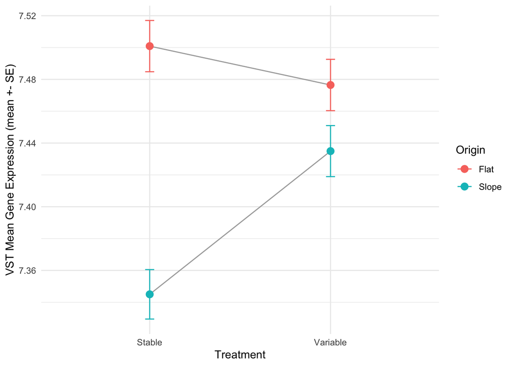

```r
 # contrast                       estimate     SE    df t.ratio p.value
 # Stable_Flat - Stable_Slope       0.1559 0.0225 9232   6.914  <.0001
 # Stable_Flat - Variable_Flat      0.0244 0.0225 9232   1.083  0.6998
 # Stable_Flat - Variable_Slope     0.0660 0.0225 9232   2.925  0.0181
 # Stable_Slope - Variable_Flat    -0.1315 0.0225 9232  -5.831  <.0001
 # Stable_Slope - Variable_Slope   -0.0900 0.0225 9232  -3.989  0.0004
 # Variable_Flat - Variable_Slope   0.0415 0.0225 9232   1.842  0.2537

#######

ggplot(group_summary, aes(x = Treatment, y = meanExp, color = Origin)) +
  geom_errorbar(aes(ymin = meanExp -  se, ymax = meanExp + se, color = Origin), width = 0.05) +
  geom_line(aes(group = Origin), color = "darkgrey") +
   geom_point(size = 3) +
  labs(x = "Treatment", y = "VST Mean Gene Expression (mean +- SE)") +
  theme_minimal()
```

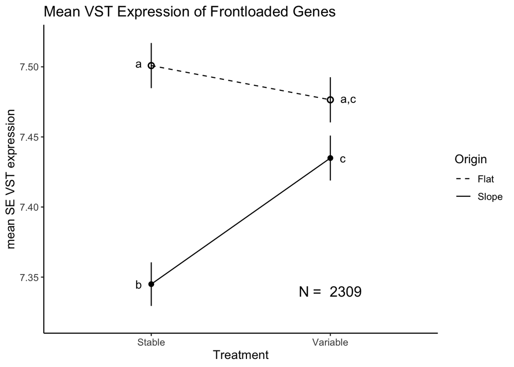

```r
P2 <- ggplot(group_summary, aes(x = Treatment, y = meanExp, fill = Origin, group = Origin)) +
  geom_line(aes(linetype = Origin), size = 0.5) +
  geom_pointrange(aes(ymin=meanExp-se, ymax=meanExp+se, shape=Origin, fill=Origin)) +
                      scale_shape_manual(values=c(1, 16))+
                      scale_fill_manual(values=c('black','white')) +
                      theme_classic() +
  scale_linetype_manual(values = c("Slope" = "solid", "Flat" = "dashed"))  +
                      labs(y= "mean SE VST expression",
                           x = "Treatment",
                           title = "Mean VST Expression of Frontloaded Genes") +
   theme(text = element_text(size=12)) +
                      scale_y_continuous(limits = c(7.32,7.52), breaks = seq(7.3,7.5, by = .05)) +
                        annotate(geom="text", x=0.93, y=7.345, label="b", color="black",size=4) +
                        annotate(geom="text", x=0.93, y=7.5025,  label="a", color="black",size=4) +
                        annotate(geom="text", x=2.07, y=7.435, label="c", color="black",size=4) +
                        annotate(geom="text", x=2.1, y=7.4775,  label="a,c", color="black",size=4) +
                        annotate(geom="text", x = 2, y = 7.34, label=paste("N = ",group_summary$n[1]), size = 5) + guides(fill = FALSE, shape = FALSE)
P2
```

```r
ggsave("~/Documents/URI/Heron-Pdam-gene-expression/BioInf/output/glmmseq/frontloaded_figures/VST_frontloaded.pdf", plot =P2, width= 7, height = 5)
```

```r
# Normality test
shapiro.test(vst_summary$mean_val[vst_summary$Treatment == "Stable" & vst_summary$Origin == "Slope"])
```

```
##
##  Shapiro-Wilk normality test
##
## data:  vst_summary$mean_val[vst_summary$Treatment == "Stable" & vst_summary$Origin == "Slope"]
## W = 0.79834, p-value < 2.2e-16
```

```r
shapiro.test(vst_summary$mean_val[vst_summary$Treatment == "Variable" & vst_summary$Origin == "Slope"])
```

```
##
##  Shapiro-Wilk normality test
##
## data:  vst_summary$mean_val[vst_summary$Treatment == "Variable" & vst_summary$Origin == "Slope"]
## W = 0.78396, p-value < 2.2e-16
```

```r
shapiro.test(vst_summary$mean_val[vst_summary$Treatment == "Stable" & vst_summary$Origin == "Flat"])
```

```
##
##  Shapiro-Wilk normality test
##
## data:  vst_summary$mean_val[vst_summary$Treatment == "Stable" & vst_summary$Origin == "Flat"]
## W = 0.77664, p-value < 2.2e-16
```

```r
shapiro.test(vst_summary$mean_val[vst_summary$Treatment == "Variable" & vst_summary$Origin == "Flat"])
```

```
##
##  Shapiro-Wilk normality test
##
## data:  vst_summary$mean_val[vst_summary$Treatment == "Variable" & vst_summary$Origin == "Flat"]
## W = 0.7712, p-value < 2.2e-16
```

```r
# Data is not normally distributed
```

```r
# Perform Kruskal-Wallis test
kruskal_test <- kruskal.test(mean_val ~ group, data = vst_summary)

# Check the Kruskal-Wallis test results
print(kruskal_test)
```

```
##
##  Kruskal-Wallis rank sum test
##
## data:  mean_val by group
## Kruskal-Wallis chi-squared = 139.66, df = 3, p-value < 2.2e-16
```

```r
library(dunn.test)

# Conduct Dunn's post-hoc test
posthoc_dunn <- dunn.test(vst_summary$mean_val, g = vst_summary$group, method = "bonferroni")
```

```
##   Kruskal-Wallis rank sum test
##
## data: x and group
## Kruskal-Wallis chi-squared = 139.6628, df = 3, p-value = 0
##
##
##                            Comparison of x by group
##                                  (Bonferroni)
## Col Mean-|
## Row Mean |   Stable_F   Stable_S   Variable
## ---------+---------------------------------
## Stable_S |   11.00468
##          |    0.0000*
## Variable |   1.834983  -9.169702
##          |     0.1995    0.0000*
## Variable |   4.926383  -6.078303   3.091399
##          |    0.0000*    0.0000*    0.0060*
##
## alpha = 0.05
## Reject Ho if p <= alpha/2
```

```r
# Check the post-hoc test results
print(posthoc_dunn)
```

```
## $chi2
## [1] 139.6628
##
## $Z
## [1] 11.004687  1.834984 -9.169703  4.926383 -6.078303  3.091400
##
## $P
## [1] 1.813877e-28 3.325406e-02 2.371623e-20 4.188282e-07 6.073041e-10
## [6] 9.960769e-04
##
## $P.adjusted
## [1] 1.088326e-27 1.995243e-01 1.422974e-19 2.512969e-06 3.643825e-09
## [6] 5.976461e-03
##
## $comparisons
## [1] "Stable_Flat - Stable_Slope"     "Stable_Flat - Variable_Flat"
## [3] "Stable_Slope - Variable_Flat"   "Stable_Flat - Variable_Slope"
## [5] "Stable_Slope - Variable_Slope"  "Variable_Flat - Variable_Slope"
```